# **Problem statement**

### Confusion matrix

#### **Checking model performance on training set**

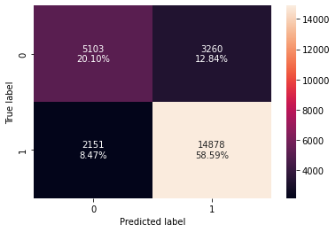

```python
confusion_matrix_statsmodels(lg1, X_train1, y_train)
```

```python
log_reg_model_train_perf = model_performance_classification_statsmodels(
    lg1, X_train1, y_train
)

print("Training performance:")
log_reg_model_train_perf
```

```
Training performance:
```

|  | Accuracy | Recall | Precision | F1 |
| --- | --- | --- | --- | --- |
| 0 | 0.786901 | 0.873686 | 0.820267 | 0.846134 |

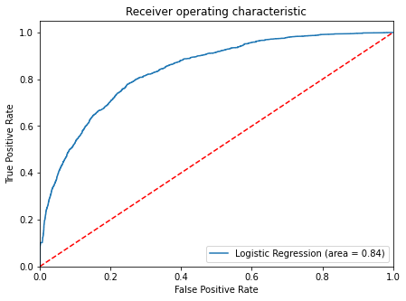

```python
from sklearn.metrics import roc_auc_score
from sklearn.metrics import roc_curve
logit_roc_auc_train = roc_auc_score(y_train, lg1.predict(X_train1))
fpr, tpr, thresholds = roc_curve(y_train, lg1.predict(X_train1))
plt.figure(figsize=(7, 5))
plt.plot(fpr, tpr, label="Logistic Regression (area = %0.2f)" % logit_roc_auc_train)
plt.plot([0, 1], [0, 1], "r--")
plt.xlim([0.0, 1.0])
plt.ylim([0.0, 1.05])
plt.xlabel("False Positive Rate")
plt.ylabel("True Positive Rate")
plt.title("Receiver operating characteristic")
plt.legend(loc="lower right")
plt.show()
```

**Optimal threshold using AUC-ROC curve**

```python
fpr, tpr, thresholds = roc_curve(y_train, lg1.predict(X_train1))

optimal_idx = np.argmax(tpr - fpr)
optimal_threshold_auc_roc = thresholds[optimal_idx]
print(optimal_threshold_auc_roc)
```

```
0.6307206653917493
```

**checking model performance for this model**

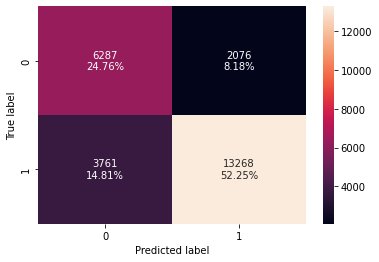

```python
confusion_matrix_statsmodels(
    lg1, X_train1, y_train, threshold=optimal_threshold_auc_roc
)
```

```python
log_reg_model_train_perf_threshold_auc_roc = model_performance_classification_statsmodels(
    lg1, X_train1, y_train, threshold=optimal_threshold_auc_roc
)
print("Training performance:")
log_reg_model_train_perf_threshold_auc_roc
```

```
Training performance:
```

|  | Accuracy | Recall | Precision | F1 |
| --- | --- | --- | --- | --- |
| 0 | 0.770124 | 0.779141 | 0.864703 | 0.819695 |

**Precision-Recall Curve**

```python
X_test1 = X_test[list(X_train1.columns)]
```

```python
from sklearn.metrics import precision_recall_curve
```

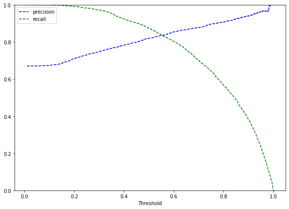

```python
y_scores = lg1.predict(X_train1)
prec, rec, tre = precision_recall_curve(y_train, y_scores,)


def plot_prec_recall_vs_tresh(precisions, recalls, thresholds):
    plt.plot(thresholds, precisions[:-1], "b--", label="precision")
    plt.plot(thresholds, recalls[:-1], "g--", label="recall")
    plt.xlabel("Threshold")
    plt.legend(loc="upper left")
    plt.ylim([0, 1])



plt.figure(figsize=(10, 7))
plot_prec_recall_vs_tresh(prec, rec, tre)
plt.show()
```

```python
optimal_threshold_curve = 0.56
```

Checking model performance on training set

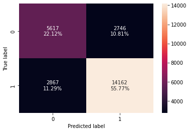

```python
confusion_matrix_statsmodels(lg1, X_train1, y_train, threshold=optimal_threshold_curve)
```

```python
log_reg_model_train_perf_threshold_curve = model_performance_classification_statsmodels(
    lg1, X_train1, y_train, threshold=optimal_threshold_curve
)
print("Training performance:")
log_reg_model_train_perf_threshold_curve
```

```
Training performance:
```

|  | Accuracy | Recall | Precision | F1 |
| --- | --- | --- | --- | --- |
| 0 | 0.778946 | 0.83164 | 0.837592 | 0.834605 |

- Model is performing well on training set.

### **Checking model performance on test set**

```python
X_test1 = X_test[list(X_train1.columns)]
```

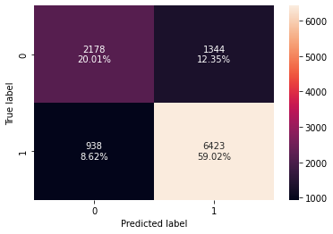

```python
confusion_matrix_statsmodels(lg1, X_test1, y_test)
```

```python
log_reg_model_test_perf = model_performance_classification_statsmodels(
    lg1, X_test1, y_test
)

print("Test performance:")
log_reg_model_test_perf
```

```
Test performance:
```

|  | Accuracy | Recall | Precision | F1 |
| --- | --- | --- | --- | --- |
| 0 | 0.790315 | 0.872572 | 0.82696 | 0.849154 |

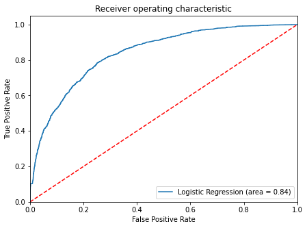

```python
logit_roc_auc_train = roc_auc_score(y_test, lg1.predict(X_test1))
fpr, tpr, thresholds = roc_curve(y_test, lg1.predict(X_test1))
plt.figure(figsize=(7, 5))
plt.plot(fpr, tpr, label="Logistic Regression (area = %0.2f)" % logit_roc_auc_train)
plt.plot([0, 1], [0, 1], "r--")
plt.xlim([0.0, 1.0])
plt.ylim([0.0, 1.05])
plt.xlabel("False Positive Rate")
plt.ylabel("True Positive Rate")
plt.title("Receiver operating characteristic")
plt.legend(loc="lower right")
plt.show()
```

1. Threshold of 0.630

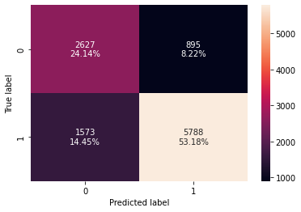

```python
confusion_matrix_statsmodels(lg1, X_test1, y_test, threshold=optimal_threshold_auc_roc)
```

```python
log_reg_model_test_perf_threshold_auc_roc = model_performance_classification_statsmodels(
    lg1, X_test1, y_test, threshold=optimal_threshold_auc_roc
)
print("Test performance:")
log_reg_model_test_perf_threshold_auc_roc
```

```
Test performance:
```

|  | Accuracy | Recall | Precision | F1 |
| --- | --- | --- | --- | --- |
| 0 | 0.773224 | 0.786306 | 0.866078 | 0.824267 |

1. Threshold of 0.56

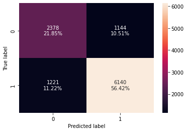

```python
confusion_matrix_statsmodels(lg1, X_test1, y_test, threshold=optimal_threshold_curve)
```

```python
log_reg_model_test_perf_threshold_curve = model_performance_classification_statsmodels(
    lg1, X_test1, y_test, threshold=optimal_threshold_curve
)
print("Test performance:")
log_reg_model_test_perf_threshold_curve
```

```
Test performance:
```

|  | Accuracy | Recall | Precision | F1 |
| --- | --- | --- | --- | --- |
| 0 | 0.782689 | 0.834126 | 0.842943 | 0.838511 |

### **Model Performance Comparison and Final Model Selection**

```python
models_train_comp_df = pd.concat(
    [
        log_reg_model_train_perf.T,
        log_reg_model_train_perf_threshold_auc_roc.T,
        log_reg_model_train_perf_threshold_curve.T,
    ],
    axis=1,
)
models_train_comp_df.columns = [
    "Logistic Regression-default Threshold (0.5)",
    "Logistic Regression-0.63 Threshold",
    "Logistic Regression-0.56 Threshold",
]

print("Training performance comparison:")
models_train_comp_df
```

```
Training performance comparison:
```

|  | Logistic Regression-default Threshold (0.5) | Logistic Regression-0.63 Threshold | Logistic Regression-0.56 Threshold |
| --- | --- | --- | --- |
| Accuracy | 0.786901 | 0.770124 | 0.778946 |
| Recall | 0.873686 | 0.779141 | 0.831640 |
| Precision | 0.820267 | 0.864703 | 0.837592 |
| F1 | 0.846134 | 0.819695 | 0.834605 |

```python
models_test_comp_df = pd.concat(
    [
        log_reg_model_test_perf.T,
        log_reg_model_test_perf_threshold_auc_roc.T,
        log_reg_model_test_perf_threshold_curve.T,
    ],
    axis=1,
)
models_test_comp_df.columns = [
    "Logistic Regression-default Threshold (0.5)",
    "Logistic Regression-0.63 Threshold",
    "Logistic Regression-0.56 Threshold",
]

print("Test set performance comparison:")
models_test_comp_df
```

```
Test set performance comparison:
```

|  | Logistic Regression-default Threshold (0.5) | Logistic Regression-0.63 Threshold | Logistic Regression-0.56 Threshold |
| --- | --- | --- | --- |
| Accuracy | 0.790315 | 0.773224 | 0.782689 |
| Recall | 0.872572 | 0.786306 | 0.834126 |
| Precision | 0.826960 | 0.866078 | 0.842943 |
| F1 | 0.849154 | 0.824267 | 0.838511 |

- The model with a default threshold (0.5) is giving the best F1 score. Therefore it can be selected as the final model
- Optimized threshold for stats library was found to be ~0.56 with a balanced high precision & recall.

# Building a Decision Tree model

```python
X = inn2.drop(["booking_status"], axis=1)
Y = inn2["booking_status"]

X = pd.get_dummies(X, drop_first=True)
```

```python
X_train, X_test, y_train, y_test = train_test_split(
    X, Y, test_size=0.30, random_state=1
)
```

```python
print("Percentage of classes in training set:")
print(y_train.value_counts(normalize=True))
print("Percentage of classes in test set:")
print(y_test.value_counts(normalize=True))
```

```
Percentage of classes in training set:
1    0.670644
0    0.329356
Name: booking_status, dtype: float64
Percentage of classes in test set:
1    0.676376
0    0.323624
Name: booking_status, dtype: float64
```

```python
model = DecisionTreeClassifier(criterion = 'gini', random_state=1)
```

```python
model.fit(X_train, y_train)
```

```
DecisionTreeClassifier(random_state=1)
```

```python
def confusion_matrix_sklearn(model, predictors, target):
    """
    To plot the confusion_matrix with percentages

    model: classifier
    predictors: independent variables
    target: dependent variable
    """
    y_pred = model.predict(predictors)
    cm = confusion_matrix(target, y_pred)
    labels = np.asarray(
        [
            ["{0:0.0f}".format(item) + "\n{0:.2%}".format(item / cm.flatten().sum())]
            for item in cm.flatten()
        ]
    ).reshape(2, 2)

    plt.figure(figsize=(6, 4))
    sns.heatmap(cm, annot=labels, fmt="")
    plt.ylabel("True label")
    plt.xlabel("Predicted label")
```

```python
def get_recall_score(model):
    '''
    model : classifier to predict values of X

    '''
    pred_train = model.predict(X_train)
    pred_test = model.predict(X_test)
    print("Recall on training set : ",metrics.recall_score(y_train,pred_train))
    print("Recall on test set : ",metrics.recall_score(y_test,pred_test))
```

**Checking model performance on training set**

```python
decision_tree_perf_train = model_performance_classification_sklearn(
    model, X_train, y_train
)
decision_tree_perf_train
```

|  | Accuracy | Recall | Precision | F1 |
| --- | --- | --- | --- | --- |
| 0 | 0.993305 | 0.994891 | 0.995125 | 0.995008 |

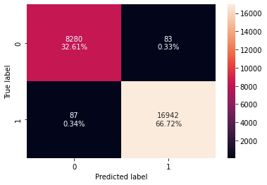

```python
confusion_matrix_sklearn(model, X_train, y_train)
```

```python
def get_perf_score(model, predictors, target):
    """
    model: classifier
    predictors: independent variables
    target: dependent variable

    """
    prediction = model.predict(predictors)
    acc = accuracy_score(target, prediction)
    recall = recall_score(target, prediction)
    precision = precision_score(target, prediction)
    f1 = f1_score(target, prediction)

    df_perf1 = pd.DataFrame({"Accuracy": acc, "Recall": recall, "Precision": precision, "F1": f1,},index=[0],)

    return df_perf1
```

**Checking model performance on test set**

```python
decision_tree_perf_test = model_performance_classification_sklearn(
    model, X_test, y_test
)
decision_tree_perf_test
```

|  | Accuracy | Recall | Precision | F1 |
| --- | --- | --- | --- | --- |
| 0 | 0.862905 | 0.892949 | 0.903257 | 0.898074 |

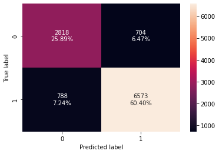

```python
confusion_matrix_sklearn(model, X_test, y_test)
```

```python
column_names = list(X.columns)
feature_names = column_names
print(feature_names)
```

```
['no_of_adults', 'no_of_children', 'no_of_weekend_nights', 'no_of_week_nights', 'avg_price_per_room', 'no_of_special_requests', 'cbrt_lead_time', 'type_of_meal_plan_Meal Plan 2', 'type_of_meal_plan_Meal Plan 3', 'type_of_meal_plan_Not Selected', 'required_car_parking_space_1', 'room_type_reserved_Ro…
```

### **Visualizing the Decision Tree**

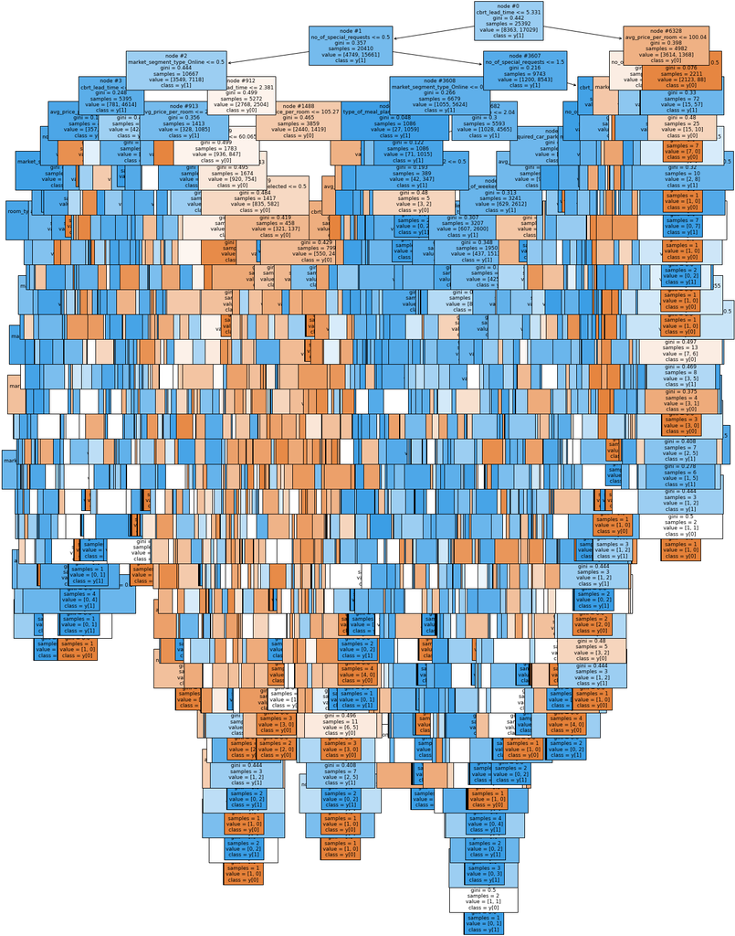

```python
plt.figure(figsize=(20, 30))

out = tree.plot_tree(
    model,
    feature_names=feature_names,
    filled=True,
    fontsize=9,
    node_ids=True,
    class_names=True,
)
for o in out:
    arrow = o.arrow_patch
    if arrow is not None:
        arrow.set_edgecolor("black")
        arrow.set_linewidth(1)
plt.show()
```

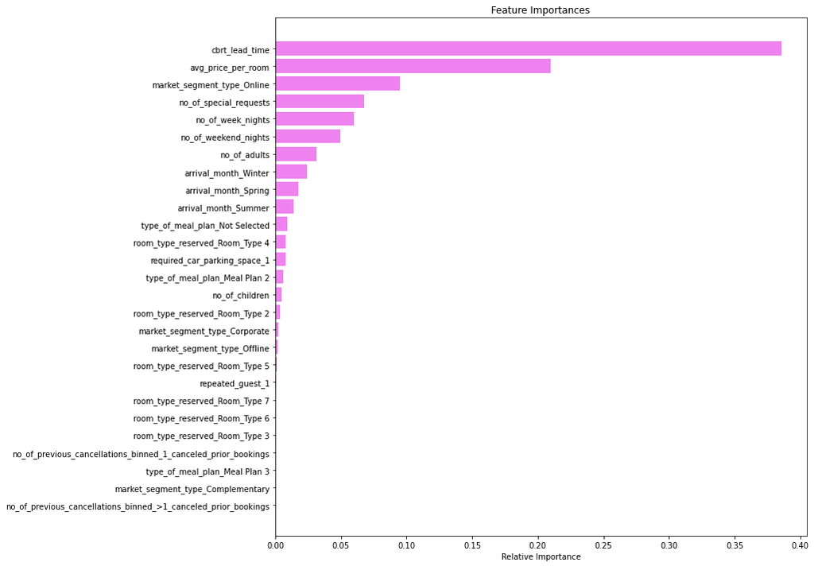

```python
importances = model.feature_importances_
indices = np.argsort(importances)

plt.figure(figsize=(12, 12))
plt.title("Feature Importances")
plt.barh(range(len(indices)), importances[indices], color="violet", align="center")
plt.yticks(range(len(indices)), [feature_names[i] for i in indices])
plt.xlabel("Relative Importance")
plt.show()
```

```python
print (pd.DataFrame(model.feature_importances_, columns = ["Imp"], index = X_train.columns).sort_values(by = 'Imp', ascending = False))
```

```
                                                         Imp
cbrt_lead_time                                      0.385482
avg_price_per_room                                  0.209710
market_segment_type_Online                          0.094839
no_of_special_requests                              0.067941
no_of_week_nights                                   0.060158
no_of_weekend_nights                                0.049344
no_of_adults                                        0.031501
arrival_month_Winter                                0.024162
arrival_month_Spring                                0.017259
arrival_month_Summer                                0.013656
type_of_meal_plan_Not Selected                      0.009302
room_type_reserved_Room_Type 4                      0.008050
required_car_parking_space_1                        0.007594
type_of_meal_plan_Meal Plan 2                       0.005843
no_of_children                                      0.004839
room_type_reserved_Room_Type 2                      0.003450
market_segment_type_Corporate                       0.002347
market_segment_type_Offline                         0.002136
room_type_reserved_Room_Type 5                      0.001216
repeated_guest_1                                    0.000617
room_type_reserved_Room_Type 7                      0.000312
room_type_reserved_Room_Type 6                      0.000230
room_type_reserved_Room_Type 3                      0.000013
type_of_meal_plan_Meal Plan 3                       0.000000
market_segment_type_Complementary                   0.000000
no_of_previous_cancellations_binned_1_canceled_...  0.000000
no_of_previous_cancellations_binned_>1_canceled...  0.000000
```

#### **Decision Tree (Pre-pruning)**

**Pre prune the model with max depth hyperparameter**

```python
estimator = DecisionTreeClassifier(random_state=1)



parameters = {
    "max_depth": [5, 10, 15],
    "criterion": ["entropy", "gini"],
    "splitter": ["best", "random"],
    "min_impurity_decrease": [0.000001, 0.00001],
}


acc_scorer = make_scorer(f1_score)


grid_obj = GridSearchCV(estimator, parameters, scoring=acc_scorer, cv=5)
grid_obj = grid_obj.fit(X_train, y_train)


estimator = grid_obj.best_estimator_


estimator.fit(X_train, y_train)
```

```
DecisionTreeClassifier(criterion='entropy', max_depth=15,
                       min_impurity_decrease=1e-06, random_state=1)
```

**Checking performance on training set**

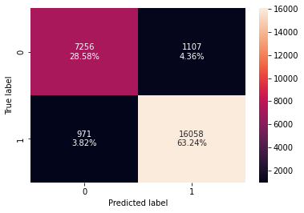

```python
confusion_matrix_sklearn(estimator, X_train, y_train)
```

```python
decision_tree_tune_perf_train = model_performance_classification_sklearn(
    estimator, X_train, y_train
)
decision_tree_tune_perf_train
```

|  | Accuracy | Recall | Precision | F1 |
| --- | --- | --- | --- | --- |
| 0 | 0.918163 | 0.94298 | 0.935508 | 0.939229 |

```python
decision_tree_tune_perf_test = model_performance_classification_sklearn(
    estimator, X_test, y_test
)

decision_tree_tune_perf_test
```

|  | Accuracy | Recall | Precision | F1 |
| --- | --- | --- | --- | --- |
| 0 | 0.873013 | 0.95843 | 0.867667 | 0.910793 |

[figure not shown]

```python
confusion_matrix_sklearn(estimator, X_test, y_test)
```

The f1 score has improved on the testing set as compared to the initial mode

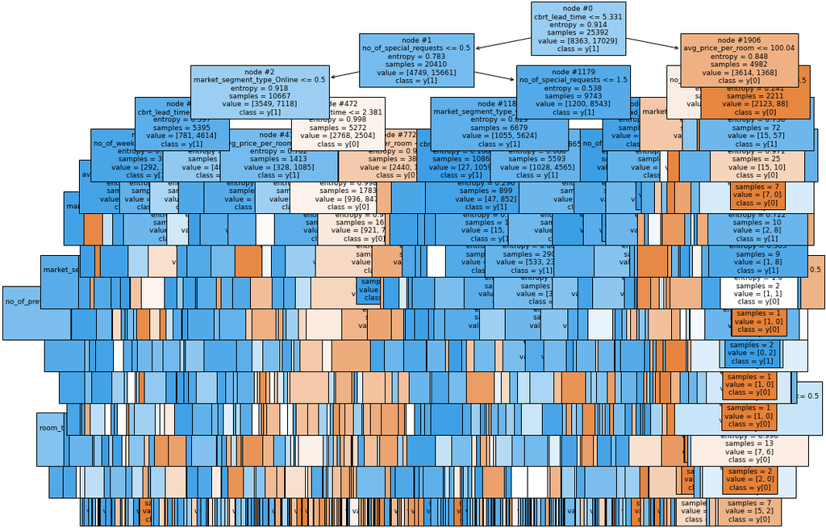

```python
plt.figure(figsize=(15, 12))

tree.plot_tree(
    estimator,
    feature_names=feature_names,
    filled=True,
    fontsize=9,
    node_ids=True,
    class_names=True,
)
plt.show()
```

### Cost Complexity Pruning

```python
clf = DecisionTreeClassifier(random_state=1)
path = clf.cost_complexity_pruning_path(X_train, y_train)
ccp_alphas, impurities = path.ccp_alphas, path.impurities
```

```python
pd.DataFrame(path)
```

|  | ccp_alphas | impurities |
| --- | --- | --- |
| 0 | 0.000000e+00 | 0.008631 |
| 1 | 1.842455e-07 | 0.008631 |
| 2 | 4.688391e-07 | 0.008632 |
| 3 | 5.329960e-07 | 0.008632 |
| 4 | 5.967043e-07 | 0.008633 |
| ... | ... | ... |
| 1456 | 6.665684e-03 | 0.286897 |
| 1457 | 1.304480e-02 | 0.299942 |
| 1458 | 1.725993e-02 | 0.317202 |
| 1459 | 2.399048e-02 | 0.365183 |
| 1460 | 7.657789e-02 | 0.441761 |

1461 rows × 2 columns

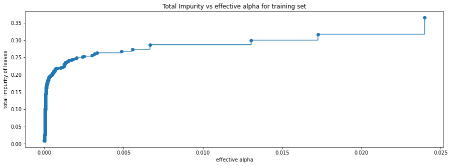

```python
fig, ax = plt.subplots(figsize=(15, 5))
ax.plot(ccp_alphas[:-1], impurities[:-1], marker="o", drawstyle="steps-post")
ax.set_xlabel("effective alpha")
ax.set_ylabel("total impurity of leaves")
ax.set_title("Total Impurity vs effective alpha for training set")
plt.show()
```

Next, we train a decision tree using the effective alphas. The last value in ccp_alphas is the alpha value that prunes the whole tree, leaving the tree, clfs[-1], with one node.

```python
clfs = []
for ccp_alpha in ccp_alphas:
    clf = DecisionTreeClassifier(random_state=1, ccp_alpha=ccp_alpha)
    clf.fit(X_train, y_train)
    clfs.append(clf)
print("Number of nodes in the last tree is: {} with ccp_alpha: {}".format(
      clfs[-1].tree_.node_count, ccp_alphas[-1]))
```

```
Number of nodes in the last tree is: 1 with ccp_alpha: 0.07657789477371346
```

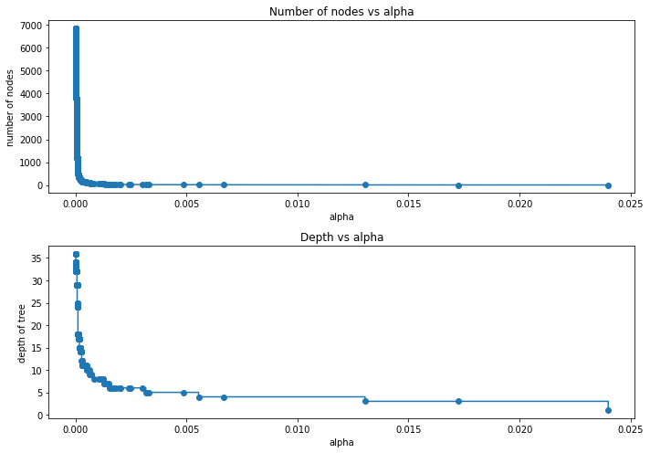

```python
clfs = clfs[:-1]
ccp_alphas = ccp_alphas[:-1]

node_counts = [clf.tree_.node_count for clf in clfs]
depth = [clf.tree_.max_depth for clf in clfs]
fig, ax = plt.subplots(2, 1,figsize=(10,7))
ax[0].plot(ccp_alphas, node_counts, marker='o', drawstyle="steps-post")
ax[0].set_xlabel("alpha")
ax[0].set_ylabel("number of nodes")
ax[0].set_title("Number of nodes vs alpha")
ax[1].plot(ccp_alphas, depth, marker='o', drawstyle="steps-post")
ax[1].set_xlabel("alpha")
ax[1].set_ylabel("depth of tree")
ax[1].set_title("Depth vs alpha")
fig.tight_layout()
```

For the remainder, we remove the last element in clfs and ccp_alphas, because it is the trivial tree with only one node

```python
f1_train = []
for clf in clfs:
    pred_train = clf.predict(X_train)
    values_train = f1_score(y_train, pred_train)
    f1_train.append(values_train)
```

```python
f1_test = []
for clf in clfs:
    pred_test = clf.predict(X_test)
    values_test = f1_score(y_test, pred_test)
    f1_test.append(values_test)
```

```python
train_scores = [clf.score(X_train, y_train) for clf in clfs]
test_scores = [clf.score(X_test, y_test) for clf in clfs]
```

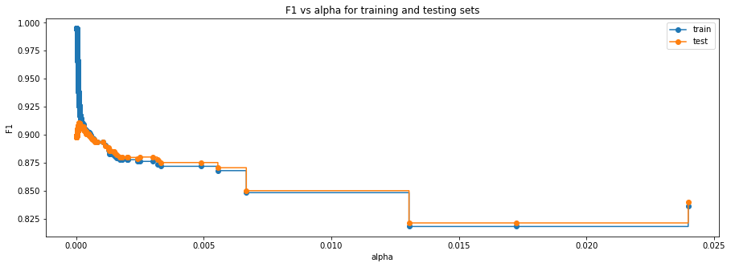

```python
fig, ax = plt.subplots(figsize=(15, 5))
ax.set_xlabel("alpha")
ax.set_ylabel("F1")
ax.set_title("F1 vs alpha for training and testing sets")
ax.plot(
    ccp_alphas, f1_train, marker="o", label="train", drawstyle="steps-post",
)
ax.plot(ccp_alphas, f1_test, marker="o", label="test", drawstyle="steps-post")
ax.legend()
plt.show()
```

creating the model where we get highest train and test f1_score

```python
index_best_model = np.argmax(f1_test)
best_model = clfs[index_best_model]
print(best_model)
```

```
DecisionTreeClassifier(ccp_alpha=9.198316674134987e-05, random_state=1)
```

Checking performance on the training set

```python
decision_tree_postpruned_perf_train = get_perf_score(best_model, X_train, y_train)
decision_tree_postpruned_perf_train
```

|  | Accuracy | Recall | Precision | F1 |
| --- | --- | --- | --- | --- |
| 0 | 0.908751 | 0.950496 | 0.916535 | 0.933206 |

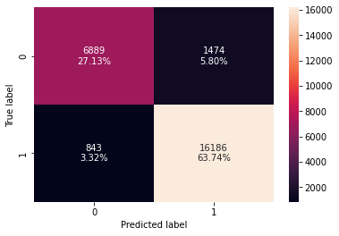

```python
confusion_matrix_sklearn(best_model, X_train, y_train)
```

Checking performance on the test set

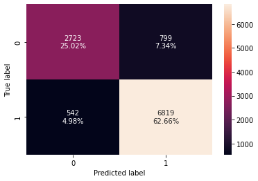

```python
confusion_matrix_sklearn(best_model, X_test, y_test)
```

```python
decision_tree_postpruned_perf_test = get_perf_score(best_model, X_test, y_test)
decision_tree_postpruned_perf_test
```

|  | Accuracy | Recall | Precision | F1 |
| --- | --- | --- | --- | --- |
| 0 | 0.87678 | 0.926369 | 0.895117 | 0.910475 |

With post-pruning we are getting good and generalized model performance on both training and test set.

**Visualizing the Decision Tree**

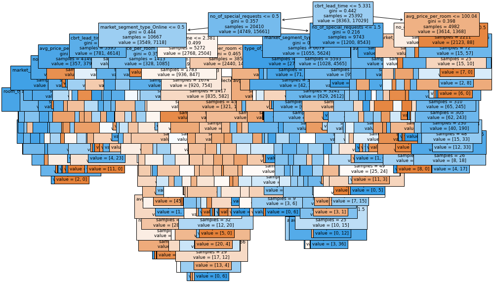

```python
plt.figure(figsize=(15, 10))

out = tree.plot_tree(
    best_model,
    feature_names=feature_names,
    filled=True,
    fontsize=9,
    node_ids=False,
    class_names=None,
)
for o in out:
    arrow = o.arrow_patch
    if arrow is not None:
        arrow.set_edgecolor("black")
        arrow.set_linewidth(1)
plt.show()
```

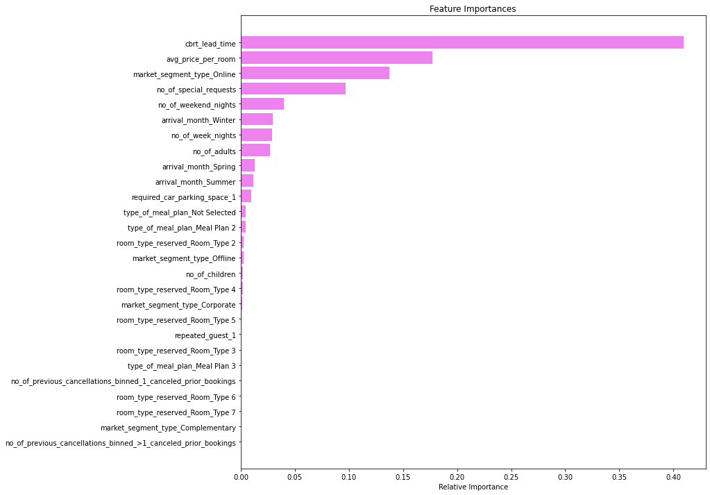

```python
importances = best_model.feature_importances_
indices = np.argsort(importances)

plt.figure(figsize=(12, 12))
plt.title("Feature Importances")
plt.barh(range(len(indices)), importances[indices], color="violet", align="center")
plt.yticks(range(len(indices)), [feature_names[i] for i in indices])
plt.xlabel("Relative Importance")
plt.show()
```

```python
print(
    pd.DataFrame(
        best_model.feature_importances_, columns=["Imp"], index=X_train.columns
    ).sort_values(by="Imp", ascending=False)
)
```

```
                                                         Imp
cbrt_lead_time                                      0.409247
avg_price_per_room                                  0.177422
market_segment_type_Online                          0.137339
no_of_special_requests                              0.097069
no_of_weekend_nights                                0.039614
arrival_month_Winter                                0.029479
no_of_week_nights                                   0.028905
no_of_adults                                        0.026726
arrival_month_Spring                                0.012572
arrival_month_Summer                                0.011388
required_car_parking_space_1                        0.009574
type_of_meal_plan_Not Selected                      0.004802
type_of_meal_plan_Meal Plan 2                       0.004593
room_type_reserved_Room_Type 2                      0.002772
market_segment_type_Offline                         0.002421
no_of_children                                      0.002222
room_type_reserved_Room_Type 4                      0.001706
market_segment_type_Corporate                       0.001269
room_type_reserved_Room_Type 5                      0.000716
repeated_guest_1                                    0.000165
room_type_reserved_Room_Type 7                      0.000000
room_type_reserved_Room_Type 6                      0.000000
market_segment_type_Complementary                   0.000000
room_type_reserved_Room_Type 3                      0.000000
type_of_meal_plan_Meal Plan 3                       0.000000
no_of_previous_cancellations_binned_1_canceled_...  0.000000
no_of_previous_cancellations_binned_>1_canceled...  0.000000
```

- cbrt_lead_time, avg_price_per_room and market_segment_type_Online were found to be important parameters to predict cancelations

**Comparison of Models and Final Model Selection**

```python
models_train_comp_df = pd.concat(
    [
        decision_tree_perf_train.T,
        decision_tree_tune_perf_train.T,
        decision_tree_postpruned_perf_train.T,
    ],
    axis=1,
)
models_train_comp_df.columns = [
    "Decision Tree sklearn",
    "Decision Tree (Pre-Pruning)",
    "Decision Tree (Post-Pruning)",
]
print("Training performance comparison:")
models_train_comp_df
```

```
Training performance comparison:
```

|  | Decision Tree sklearn | Decision Tree (Pre-Pruning) | Decision Tree (Post-Pruning) |
| --- | --- | --- | --- |
| Accuracy | 0.993305 | 0.918163 | 0.908751 |
| Recall | 0.994891 | 0.942980 | 0.950496 |
| Precision | 0.995125 | 0.935508 | 0.916535 |
| F1 | 0.995008 | 0.939229 | 0.933206 |

```python
models_train_comp_df = pd.concat(
    [
        decision_tree_perf_test.T,
        decision_tree_tune_perf_test.T,
        decision_tree_postpruned_perf_test.T,
    ],
    axis=1,
)
models_train_comp_df.columns = [
    "Decision Tree sklearn",
    "Decision Tree (Pre-Pruning)",
    "Decision Tree (Post-Pruning)",
]
print("Test set performance comparison:")
models_train_comp_df
```

```
Test set performance comparison:
```

|  | Decision Tree sklearn | Decision Tree (Pre-Pruning) | Decision Tree (Post-Pruning) |
| --- | --- | --- | --- |
| Accuracy | 0.862905 | 0.873013 | 0.876780 |
| Recall | 0.892949 | 0.958430 | 0.926369 |
| Precision | 0.903257 | 0.867667 | 0.895117 |
| F1 | 0.898074 | 0.910793 | 0.910475 |

# **Conclusions and Recommendations**

- The three most important variables in terms of cancellations were the lead time, average price of the room and market segment type online.
- Lead time is most important feature with a longer lead time increasing the odds for cancelations.
- During the online booking process, offering addtional customizations or special request would help reduce the likelihood of a cancelled booking.
- Average price of room should be studied to ensure the hotel is charging a reasonable amount.
- The repeat guests have a lower rate of cancelations. The hotel should have some kind of reward or loyalty program for reapted guests.
- Policies need to be introduced to restrict how far in advance bookings can be made before the check in date.
- Majority of customers preferred Room Type 1.Other room types should be marketed.
- Bookings with more number of special requests have very low chances of cancelations. These special requests should be evalauted to satisfy guests.